```python
import numpy as np
```

# Komplexe Zahlen

Komplexe Zahlen werden definiert als die Summe einer reellen Zahl $a$ und dem Produkt einer anderen reellen Zahl $b$ mit der imaginären Zahl/Einheit $i$.

$$ \begin{align} c := a + b \cdot i\\ a, b \in \mathbb{R}; \ c \in \mathbb{C} \end{align} $$

**Beispiele:**

- $1 + 3i$
- $-1 -i$
- $i$
- $3 + 0i$ ($= 3$)

## Die imaginäre Einheit $i$

Das Konzept der imaginären Einheit $i$ wurde ursprünglich eingeführt, um folgende Gleichung zu lösen: $$x^2 + 1 = 0$$

Gleichungsumformumg (nach $x$ auflösen): $$ \begin{align} x^2 + 1 &= 0 & | & - 1\\ x^2 &= -1 & | & \sqrt{} \\ x &= \pm \sqrt{-1} \end{align} $$

Diese Gleichung hat keine reellen Lösungen, da das Quadrat einer reellen Zahl immer positiv ist.

Wenn wir jedoch eine neue Zahl $i$ so definieren, dass $i^2 = -1$ ist, dann können wir Lösungen für diese Gleichung in Form von komplexen Zahlen finden: $x = \pm i$.

$i$ ist also die imaginäre Einheit, definiert als $$i^2 = -1$$ oder $$i = \sqrt{-1}$$

## Reelle Zahlenachse

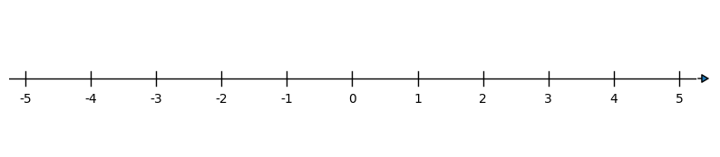

```python
import numpy as np
import matplotlib.pyplot as plt

# create a figure and a signle subplot
fig, ax = plt.subplots(figsize=(10, 2))

# set the range of the number line
ax.set_xlim(-5.25, 5.5)
ax.set_ylim(-1, 1)

# hide the axes
ax.axis('off')

# draw a line for the number line
ax.plot([-5.25, 5.25], [0, 0], 'k-', lw=1)

# draw ticks and labels for integers from -5 to 5
for i in range(-5, 6):
    ax.plot([i, i], [-0.1, 0.1], 'k-', lw=1)
    ax.text(i, -0.3, str(i), ha='center', va='center')

# add an arrow to indicate the positive direction
ax.annotate('', xy=(5.5, 0), xytext=(5.25, 0),
            arrowprops=dict(arrowstyle="-|>,head_length=0.5,head_width=0.3",
                            lw=1))

plt.show()
```

## Komplexe Zahlenebene

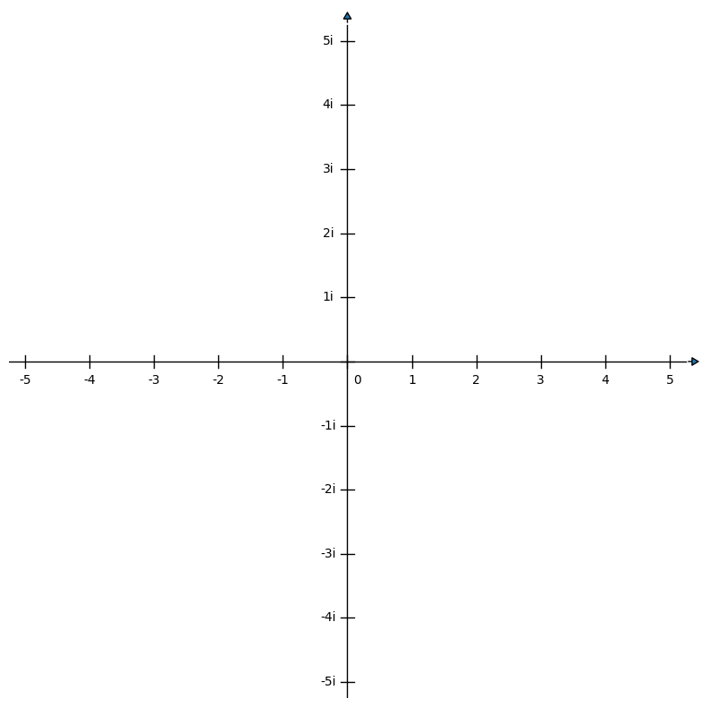

```python
import numpy as np
import matplotlib.pyplot as plt

# create a figure and a signle subplot
fig, ax = plt.subplots(figsize=(10, 10))

# set the range of the number line
ax.set_xlim(-5.25, 5.5)
ax.set_ylim(-5.25, 5.5)

# hide the axes
ax.axis('off')


# -------------------------------------------------------
# draw a horizontal line for the real number line
ax.plot([-5.25, 5.25], [0, 0], 'k-', lw=1)

# draw ticks and labels for integers from -5 to 5
for i in range(-5, 6):
    ax.plot([i, i], [-0.1, 0.1], 'k-', lw=1)
    if i != 0:
        ax.text(i, -0.3, str(i), ha='center', va='center')
    else:
        ax.text(i + 0.15, -0.3, str(i), ha='center', va='center')

# add an arrow to indicate the positive direction
ax.annotate('', xy=(5.5, 0), xytext=(5.25, 0),
            arrowprops=dict(arrowstyle="-|>,head_length=0.5,head_width=0.3",
                            lw=1))

# -------------------------------------------------------
# draw a vertical line for the imaginary number line
ax.plot([0, 0], [-5.25, 5.25], 'k-', lw=1)

# draw ticks and labels for integers from -5 to 5
for i in range(-5, 6):
    ax.plot([-0.1, 0.1], [i, i], 'k-', lw=1)
    if i != 0: # avoid labelling the origin twice
        ax.text(-0.3, i, f'{i}i', ha='center', va='center')

# add an arrow to indicate the positive direction
ax.annotate('', xy=(0, 5.5), xytext=(0, 5.25),
            arrowprops=dict(arrowstyle="-|>,head_length=0.5,head_width=0.3",
                            lw=1))

plt.show()
```

## Komplexe Zahlen in Python

```python
c = 2 + 1j

print('Typ: ', type(c))
print('Zahl: ', c)
print('Realer und imaginärer Anteil: ', c.real, ',', c.imag)
```

```
Typ:  <class 'complex'>
Zahl:  (2+1j)
Realer und imaginärer Anteil:  2.0 , 1.0
```

## Operationen mit komplexen Zahlen

### Addition

Gegeben sind zwei komplexe Zahlen:

- $z_1 = a + bi$ und
- $z_2 = c + di$ Die Summe ist definiert als: $$z_1 + z_2 = (a + c) + (b + d) i$$

Beispiel: $$(3 + 2i) + (0 - 3i) = (3 + 0) + (2 - 3) i = 3 - i$$

```python
z_1 = 3 + 2j
z_2 = 0 - 3j

z_1 + z_2
```

```
(3-1j)
```

### Multiplikation

Gegeben sind zwei komplexe Zahlen:

- $z_1 = a + bi$ und
- $z_2 = c + di$ Die Multiplikation ist definiert als: $$z_1 \cdot z_2 = (a + b i)(c + di) = ac + ad i + bc i + bd i^2$$ Erinnert euch daran, dass $i^2 = -1$, sodass wir weiter vereinfachen können:$$z_1 \cdot z_2 = (ac - bd) + (ad + bc) i$$

```python
z_1 = -1 + 2j
z_2 = 3 - 1j

z_1 * z_2
```

```
(-1+7j)
```

$$z_1 \cdot z_2 = (-1 + 2i) \cdot (3 - i) = (-3 - (-2)) + (1 + 6) i = -1 + 7i$$

### Nachtrag: Division

Gegeben sind zwei komplexe Zahlen:

- $z_1 = a + bi$ und
- $z_2 = c + di$ Die Division ist definiert als: $$\dfrac{z_1}{z_2} = \dfrac{(a + b i)}{(c + di)}$$ Jetzt ein Trick, indem wir Zähler und Nenner mit dem Konjugat des Nenners multiplizieren: $$\begin{align} \dfrac{(a + b i) \cdot (c - di)}{(c + di) \cdot (c - di)} =\\ \dfrac{(ac + bd) + (-ad + bc)i}{(c^2 - (-d \cdot d)) + (-cd + cd) i} =\\ \dfrac{(ac + bd) + (bc - ad)i}{(c^2 + d^2)} = \\ \left( \dfrac{ac + bd}{c^2 + d^2} \right) + \left( \dfrac{bc - ad}{c^2 + d^2} \right) i \end{align}$$

### Konjugat

$z = a + bi$

$\overline{z} = a - bi$

```python
print(z_1)

print(np.conjugate(z_1))
```

```
(-1+2j)
(-1-2j)
```

### Inverse

$z_{\text{inv}} = \dfrac{1}{z}$

Mit der Eigenschaft:

$z_{\text{inv}} \cdot z = 1$

### Absoluter Wert (= Modulus / Magnitude)

Der absolute Wert (Modulus / Magnitude) einer komplexen Zahl $z = a + bi$ ist $|z| = \sqrt{a^2 + b^2}$.

Alternativ kann der absolute Wert auch durch die Quadratwurzel der Multiplikation mit ihrem Konjugat ermittelt werden: $|z| = \sqrt{z \cdot \overline{z}}$. (Das Produkt ergibt immer eine reale Zahl (imaginärer Anteil = 0) und ist immer positiv.)

```python
z_1 = 2 + 1j

print(z_1)

print(np.sqrt(z_1.real ** 2 + z_1.imag ** 2))
print(np.sqrt(z_1 * np.conjugate(z_1)))
print(np.abs(z_1))
```

```
(2+1j)
2.23606797749979
(2.23606797749979+0j)
2.23606797749979
```

### Winkel (Argument)

$$\text{atan2}(y, x) \to \begin{cases} \arctan\left(\frac{y}{x}\right) & \text{for } x > 0 \\ \arctan\left(\frac{y}{x}\right) + \pi & \text{for } x < 0, y \geq 0 \\ \arctan\left(\frac{y}{x}\right) - \pi & \text{for } x < 0, y < 0 \\ \frac{\pi}{2} & \text{for } x = 0, y > 0 \\ -\frac{\pi}{2} & \text{for } x = 0, y < 0 \\ 0 & \text{for } x = 0, y = 0 \end{cases}$$

```python
print(np.arctan2(z_1.imag, z_1.real)/ np.pi * 180 )
print(np.angle(z_1)/ np.pi * 180)
```

```
26.565051177077986
26.565051177077986
```